# Sm-Nd, K-Ar and Ar-Ar geochronology

Dr. Ahmad Redaa

2024-09-17

# Sm-Nd geochronology

- **<sup>147</sup><sub>62</sub>Sm → <sup>143</sup><sub>60</sub>Nd**:
  - <sup>147</sup>Sm decays via **alpha decay** to produce <sup>143</sup>Nd.
- **Decay Constant (λ)**:
  - **6.54 x 10⁻¹² year⁻¹**.
- **Half-Life**:
  - **106 billion years**.
- **Age Calculation Equation:**

$$\frac{{^{143}\text{Nd}}}{{^{144}\text{Nd}}} = \left(
\frac{{^{143}\text{Nd}}}{{^{144}\text{Nd}}} \right)_{i} +
\frac{{^{147}\text{Sm}}}{{^{144}\text{Nd}}} \times (e^{\lambda t} - 1)$$

$$\text{Age} = \frac{ \ln(\text{slope} + 1)}{\lambda}$$

Where:
$$\text{slope} = \frac{{\frac{{^{143}\text{Nd}}}{{^{144}\text{Nd}}} -
\left( \frac{{^{143}\text{Nd}}}{{^{144}\text{Nd}}}
\right)_{i}}}{{\frac{{^{147}\text{Sm}}}{{^{144}\text{Nd}}}}}$$

- **Applications**
  - Dating Precambrian Mafic Rocks
  - High-Grade Metamorphic Rocks
  - Garnet Geochronology

# Epsilon Nd (εNd)

- **Epsilon Neodymium (εNd)**:
  - A measure of the deviation of a sample’s ¹⁴³Nd/¹⁴⁴Nd ratio from the Chondritic Uniform Reservoir (CHUR) in parts per 10,000.

$$εNd(t) = \left(
\frac{(^{143}Nd/^{144}Nd)_{sample}}{(^{143}Nd/^{144}Nd)_{CHUR}} - 1
\right) \times 10,000$$

- **CHUR**: The reference isotopic composition representing the average mantle or primitive Earth.
- **Positive εNd values**: Indicate a **depleted mantle** source (mantle-derived).
- **Negative εNd values**: Suggest an **enriched** or crustal source.

**Example**:

- Sample $^{143}Nd/^{144}Nd = 0.512500$
- CHUR $^{143}Nd/^{144}Nd = 0.512638$

$$εNd = \left( \frac{0.512500}{0.512638} - 1 \right) \times 10,000 = -2.7$$

# K-Ar geochronology

## **Why is K-Ar important in geochronology?**

- **40Ar** is a **rare gas** that accumulates in rocks after 40K decays.
  - **99.6% of atmospheric argon** comes from this decay.
- Since **40Ar** does not escape from minerals easily, we can use the **K-Ar method** to date rocks.
  - Especially useful for **volcanic and metamorphic rocks**.
  - Provides information on the **timing of volcanic eruptions** or **metamorphic events**.

## **K-Ar Dating Equations**:

1. **General Age Equation**:

$$\frac{^{40}\text{Ar}}{^{36}\text{Ar}}_{\text{total}} =
\frac{^{40}\text{Ar}}{^{36}\text{Ar}}_{\text{atm+excess}} +
\frac{^{40}\text{K}}{^{36}\text{Ar}} \times
\frac{\lambda_{EC}}{\lambda_{EC} + \lambda_{\beta}}
(e^{\lambda_{\text{total}} t} - 1)$$

Where:  
- **40Ar/36Ar_total** = total measured argon isotope ratio.  
- **40Ar/36Ar_atm+excess** = argon isotope ratio due to atmospheric and excess argon components.  
- **40K** = potassium-40 content in the sample.  
- **λ_EC** = electron capture decay constant (0.581 × 10⁻¹⁰ yr⁻¹).  
- **λ_β** = beta decay constant (4.962 × 10⁻¹⁰ yr⁻¹).  
- **λ_total** = total decay constant (5.543 × 10⁻¹⁰ yr⁻¹).  
- **t** = age of the sample.

# Ar-Ar Geochronology

## **What is the Ar-Ar Method?**

- **An advanced version of K-Ar dating**:
  - Instead of directly measuring **40K** and **40Ar**, the sample is irradiated in a nuclear reactor to convert **39K** into **39Ar**.
  - This allows for both **potassium** and **argon** isotopes to be measured in a single step.

## **How does the Ar-Ar Method work?**

1. **Irradiation**:
   - The sample is irradiated with fast neutrons in a reactor, converting **39K** into **39Ar**.
2. **Step-Heating**:
   - The sample is progressively heated in a vacuum, releasing argon gas at different temperatures.
   - This allows for the detection of disturbances or mixed ages in the sample.
3. **Isotopic Measurement**:
   - Both **40Ar** (radiogenic) and **39Ar** (produced from **39K**) are measured using a mass spectrometer.

## **Advantages of Ar-Ar Over K-Ar**:

- **Higher precision**:
  - By using **step-heating**, the Ar-Ar method allows for detailed analysis of argon release, which can reveal age disturbances and offer more precise results.
- **Smaller sample size**:
  - Less material is needed compared to K-Ar, and it can be applied to smaller grains.
- **One-step measurement**:
  - Both potassium and argon isotopes are measured together, reducing the potential for errors.

## **Ar-Ar Age Calculation Equations**:

1. **Irradiation Factor (J) for the standard**:

$$J = \frac{e^{\lambda t} -
1}{\frac{{^{40}\text{Ar}^{*}}}{{^{39}\text{Ar}}}}$$

Where:  
- **J** = irradiation factor, or “J-value.”  
- **λ** = decay constant (5.543 × 10⁻¹⁰ yr⁻¹).  
- **t** = age of the sample (in years).  
- **40Ar*** = radiogenic **40Ar**.  
- **39Ar** = argon produced from neutron irradiation of **39K**.

2. **General Age Equation**:

$$t = \frac{1}{\lambda} \ln \left(
\frac{{^{40}\text{Ar}_{\text{radiogenic}}}}{{^{39}\text{Ar}}} \times J +
1 \right)$$

Where:  
- **t** = age of the sample.  
- **λ** = decay constant (5.543 × 10⁻¹⁰ yr⁻¹).  
- **40Ar_radiogenic** = radiogenic argon from **40K** decay.  
- **39Ar** = argon produced from neutron irradiation of **39K**.  
- **J** = **irradiation factor** or “J-value” that accounts for the conversion of **39K** to **39Ar** during neutron irradiation.

## **Applications**:

- Dating volcanic, igneous rocks, and metamorphic rocks.
- Ideal for resolving complex geologic histories, especially those involving multiple heating or cooling events.

# Ar-Ar example

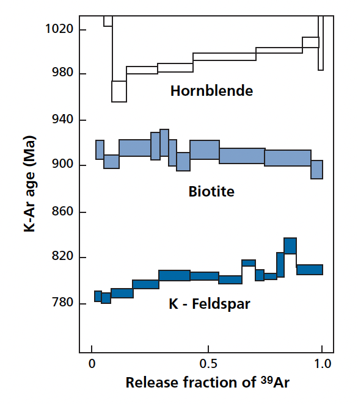

Examples of 39Ar–40Ar age spectra for three minerals from a rock aged 1000 Ma, showing sensitivity to the different minerals (from Berger and York, 1981). Source: [Allègre (2008)](https://doi.org/10.1017/CBO9780511809323)

# Further reading

- Rollinson, H.R., Rollinson, H. and Pease, V., 2021. Using geochemical data: to understand geological processes. Cambridge University Press.